# PA3

Kyle Parrish

February 18, 2021

I chose to use the dataset `lexdec`. It appears to be the results of a lexical decision task in English done by both English L1 speakers, and those who have learned English. The results are measured by correctness and reaction times. I looked at reaction time as a function of frequency in English L1 speakers, and those who have learned English.

# Libraries

```r
library(tidyverse)
library(languageR)
```

# Descriptive statistics.

```r
lexdec %>%
  group_by(NativeLanguage) %>%
  summarize(mean_rt = mean(RT), sd_rt = sd(RT), n = n())
```

```
## # A tibble: 2 x 4
##   NativeLanguage mean_rt sd_rt     n
##   <fct>            <dbl> <dbl> <int>
## 1 English           6.32 0.198   948
## 2 Other             6.47 0.264   711
```

```r
lexdec_other = lexdec %>%
  filter(NativeLanguage == "Other")

lexdec_english = lexdec %>%
  filter(NativeLanguage == "English")

t.test(lexdec_english$RT, lexdec_other$RT)
```

```
##
##  Welch Two Sample t-test
##
## data:  lexdec_english$RT and lexdec_other$RT
## t = -13.184, df = 1267.7, p-value < 2.2e-16
## alternative hypothesis: true difference in means is not equal to 0
## 95 percent confidence interval:
##  -0.1790089 -0.1326335
## sample estimates:
## mean of x mean of y
##  6.318309  6.474130
```

Here I fit models to both groups using `lm`, so that they I get a best fitting line equation for both the English group and the Other group.

# Fitting a model to investigate RT as a funcition of frequency

```r
model_english <- lm(lexdec_english$RT ~ lexdec_english$Frequency)

model_other <- lm(lexdec_other$RT ~ lexdec_other$Frequency)

summary(model_english)
```

```
##
## Call:
## lm(formula = lexdec_english$RT ~ lexdec_english$Frequency)
##
## Residuals:
##      Min       1Q   Median       3Q      Max
## -0.43874 -0.13397 -0.02276  0.10003  1.06986
##
## Coefficients:
##                           Estimate Std. Error t value Pr(>|t|)
## (Intercept)               6.466060   0.024382 265.194  < 2e-16 ***
## lexdec_english$Frequency -0.031098   0.004957  -6.274 5.35e-10 ***
## ---
## Signif. codes:  0 '***' 0.001 '**' 0.01 '*' 0.05 '.' 0.1 ' ' 1
##
## Residual standard error: 0.1945 on 946 degrees of freedom
## Multiple R-squared:  0.03995,    Adjusted R-squared:  0.03893
## F-statistic: 39.36 on 1 and 946 DF,  p-value: 5.348e-10
```

```r
summary(model_other)
```

```
##
## Call:
## lm(formula = lexdec_other$RT ~ lexdec_other$Frequency)
##
## Residuals:
##      Min       1Q   Median       3Q      Max
## -0.67232 -0.16903 -0.03787  0.13740  0.95670
##
## Coefficients:
##                         Estimate Std. Error t value Pr(>|t|)
## (Intercept)             6.752403   0.036702  183.98  < 2e-16 ***
## lexdec_other$Frequency -0.058570   0.007461   -7.85 1.54e-14 ***
## ---
## Signif. codes:  0 '***' 0.001 '**' 0.01 '*' 0.05 '.' 0.1 ' ' 1
##
## Residual standard error: 0.2536 on 709 degrees of freedom
## Multiple R-squared:  0.07997,    Adjusted R-squared:  0.07867
## F-statistic: 61.62 on 1 and 709 DF,  p-value: 1.537e-14
```

Here is the plot using `ggplot2`

# Plotting RTs in the lexical decision task by langauge group

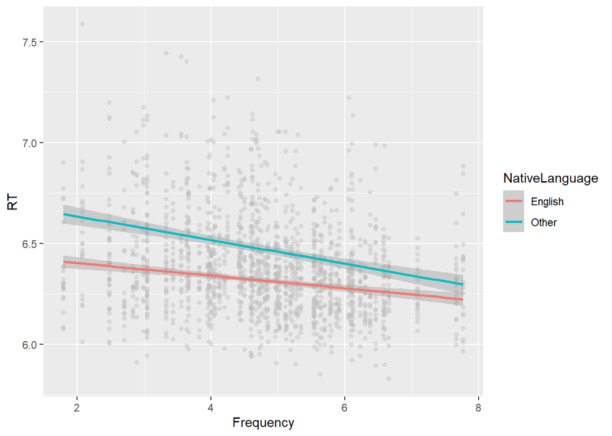

```r
ggplot(lexdec, aes(x = Frequency, y = RT, color = NativeLanguage)) + geom_point(alpha = .4, color = "gray") + geom_smooth(method = "lm")
```

# Obvervations

This was a very beneficial assignment! The dataset I chose was already rather tidy, so I did not have to use `pivot_wider` or `pivot_longer`. The results that I found seem to be a good example of why p-values alone aren’t a good nor reliable way to report whether a finding is actually “significant”, since the p-value reports how sure one is that differences in means is not equal to zero. As a dataset grows, so does the probablility that one will have a significant p-value.